# Unit 8 - Limited Dependent Variables

James Flynn

September 30, 2026

## NHL data

```r
nhl <- haven::read_dta("NHL Master Dataset.dta") %>%
    filter(year>2012) %>%
    mutate(Log_sal=log(Salary),log_points=log(Points),
           defense=Position=="D",
           d_def = as.numeric(defense)) %>%
    filter(is.na(Salary)==FALSE)
```

## Limited Dependent Variables

- Often $y$ is continuous (wages)
- Lots of outcomes we care about aren’t:
  - **Binary**: employed, insured, gave birth
  - **Unordered categorical**: occupation
  - **Ordered categorical**: self-rated health (1-5)
  - **Counts**: doctor visits, car crashes
- OLS will still *run* on all of these
  - The questions are what $\hat{\beta}$ means and when it breaks

## The Linear Probability Model (LPM)

- Just run OLS on a 0/1 outcome. Since $E[y|x] = P(y=1|x)$:

$$P(y=1|x) = \beta_0 + \beta_1
x$$

- $\beta_1$ = change in the *probability* that $y=1$ from a one-unit change in $x$
  - Percentage *points*, not percent

## Problems with LPM:

- Predicted probabilities can fall outside [0,1]
- Heteroskedastic by construction:
  - $V(u|x) = p(x)(1-p(x))$ $\implies$ **use robust SEs**
- Imposes a constant marginal effect

## Where the LPM goes wrong

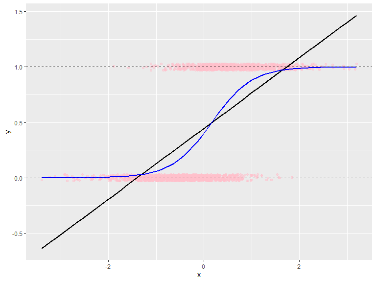

```
## [1] "Share of LPM predictions outside [0,1]"
```

```
## [1] 0.1135
```

## Logit and Probit

- Nonlinear models that keep probabilities inside [0,1]:

$$P(y=1|x) = G(\beta_0 + \beta_1
x)$$

- Logit: $G(z) = \frac{e^z}{1+e^z}$ (logistic CDF)
- Probit: $G(z) = \Phi(z)$ (standard normal CDF)

## Logit and Probit (cont’d)

- Uses maximum likelihood estimation (MLE), not OLS
- OLS - chooses parameters to minimize SSR
- MLE - chooses parameters to maximize the likelihood of observed data
- Logit vs. probit is just an assumption about the distribution of $e$
- They almost always tell the same story

## Coefficients are not marginal effects

- Take the derivative:

$$\frac{\partial P(y=1|x)}{\partial x} =
g(\beta_0 + \beta_1 x)\,\beta_1$$

- The effect depends on *where* you evaluate it
  - The sign of $\beta_1$ is interpretable, magnitude isn’t
  - **Average marginal effect (AME)**: compute for every observation, then average.
  - Marginal effect at the mean (MEM)
  - Logit only: $e^{\beta_1}$ is an *odds ratio*. Common in public health

## Predicting who’s a defenseman

```r
lpm    <- lm(d_def ~ Goals + Assists, data = nhl)
logit  <- glm(d_def ~ Goals + Assists, family = binomial(link = "logit"), data = nhl)
probit <- glm(d_def ~ Goals + Assists, family = binomial(link = "probit"), data = nhl)
msummary(list(LPM = lpm, Logit = logit, Probit = probit), stars = TRUE, coef_omit = "Intercept", gof_omit = 'AIC|BIC|Lik|Adj.|F|R2|RMSE|N')
```

|  | LPM | Logit | Probit |
| --- | --- | --- | --- |
| Goals | −0.039*** | −0.451*** | −0.240*** |
|  | (0.001) | (0.017) | (0.008) |
| Assists | 0.017*** | 0.172*** | 0.092*** |
|  | (0.001) | (0.007) | (0.004) |

+ p < 0.1, * p < 0.05, ** p < 0.01, *** p < 0.001

## What does the relationship look like?

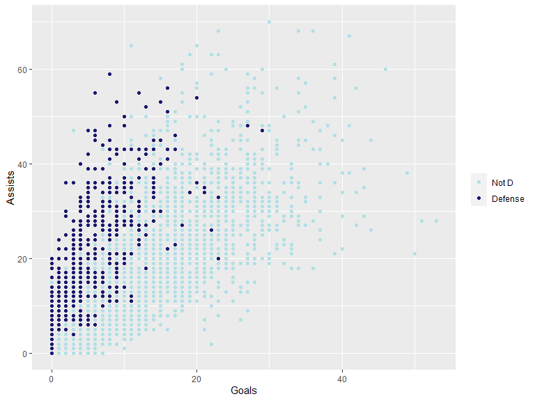

## Put them on the same scale: AMEs

```r
library(marginaleffects)
msummary(list(LPM    = avg_slopes(lpm, vcov = "HC1"),
              Logit  = avg_slopes(logit),
              Probit = avg_slopes(probit)), stars = TRUE, gof_omit = 'AIC|BIC|Lik|Adj.|F|R2|RMSE|N|Std.Errors')
```

|  | LPM | Logit | Probit |
| --- | --- | --- | --- |
| Assists | 0.017*** | 0.028*** | 0.025*** |
|  | (0.001) | (0.001) | (0.001) |
| Goals | −0.039*** | −0.073*** | −0.067*** |
|  | (0.001) | (0.002) | (0.002) |

+ p < 0.1, * p < 0.05, ** p < 0.01, *** p < 0.001

- Now all three are “change in P(defenseman) from one more goal/assist”

## So which one should I use?

- For causal work where the target is an average effect, the LPM is usually fine (Angrist & Pischke 2009)
  - AMEs from logit/probit are usually close to the LPM
  - Plays nicely with FE, DiD, IV, and clustered SEs
  - Nonlinear models + lots of FE $\implies$ *incidental parameters problem*
  - Interaction terms in nonlinear models don’t mean what you think (Ai & Norton 2003). That matters for DiD!

## So when to use logit/probit

- Reach for logit/probit when:
  - You care about predicted probabilities (prediction, classification)
  - The outcome is rare, or the mean is close to 0 or 1
  - $\uparrow$ see presentation this week
- Common practice: LPM as the main spec, logit/probit AMEs as a robustness check

## Categorical outcomes: multinomial logit

- $y$ takes $J$ unordered values (car, bus, bike)
- Pick a base category ($\beta_{base} = 0$); then for each category $j$:

$$P(y=j|x) =
\frac{e^{x\beta_j}}{\sum_{k=1}^J e^{x\beta_k}}$$

- $\beta_j$ is the log odds of $j$ *relative to the base*, so go straight to AMEs
  - AMEs across categories sum to zero (why?)
- Simple alternative: an LPM for each category dummy
  - Coefficients also sum to zero across categories

## Multinomial logit in R

```r
n <- 5000
commute <- tibble(dist = runif(n, 0, 20), inc = rnorm(n, 60, 15)) %>%
  mutate(v_car  = -2 + 0.04*inc + 0.10*dist - log(-log(runif(n))),
         v_bus  =  0                        - log(-log(runif(n))),
         v_bike = 1.5 - 0.30*dist           - log(-log(runif(n))),
         mode = c("car","bus","bike")[max.col(cbind(v_car, v_bus, v_bike))],
         mode = relevel(factor(mode), ref = "bus"))
mnl <- nnet::multinom(mode ~ dist + inc, data = commute, trace = FALSE)
avg_slopes(mnl) %>% as.data.frame() %>%
  select(group, term, estimate, std.error) %>% mutate(across(where(is.numeric), ~round(.x, 4)))
```

```
##   group term estimate std.error
## 1   bus dist  -0.0028     7e-04
## 2  bike dist  -0.0313     9e-04
## 3   car dist   0.0341     8e-04
## 4   bus  inc  -0.0047     4e-04
## 5  bike  inc  -0.0023     3e-04
## 6   car  inc   0.0070     4e-04
```

## Other limited dependent variables: a field guide

| Outcome | Example | Model | In R |
| --- | --- | --- | --- |
| Ordered | Self-rated health | Ordered logit/probit | `MASS::polr()` |
| Count | Doctor visits, goals | Poisson | `glm(family = poisson)`, `fixest::fepois()` |
| Corner solution | Hours worked, spending | Tobit | `AER::tobit()` |
| Fraction | Budget share | Fractional logit | `glm(family = quasibinomial)` |

- Poisson is nice because it handles zeros and gives you proportional (log-like) effects
- Same rule everywhere: **report marginal effects, not raw coefficients**